# Homework DV 5

Author

Lina Sinsheimer

## Question 1

```r
library(tidyverse)
wncaa <- read_csv("https://raw.githubusercontent.com/vaiseys/dav-course/main/Data/wncaa.csv")

glimpse(wncaa)
```

```
Rows: 2,092
Columns: 19
$ year              <dbl> 1982, 1982, 1982, 1982, 1982, 1982, 1982, 1982, 1982…
$ school            <chr> "Arizona St.", "Auburn", "Cheyney", "Clemson", "Drak…
$ seed              <dbl> 4, 7, 2, 5, 4, 6, 5, 8, 7, 7, 4, 8, 2, 1, 1, 2, 3, 6…
$ conference        <chr> "Western Collegiate", "Southeastern", "Independent",…
$ conf_w            <dbl> NA, NA, NA, 6, NA, NA, NA, NA, NA, NA, NA, NA, NA, N…
$ conf_l            <dbl> NA, NA, NA, 3, NA, NA, NA, NA, NA, NA, NA, NA, NA, N…
$ conf_percent      <dbl> NA, NA, NA, 66.7, NA, NA, NA, NA, NA, NA, NA, NA, NA…
$ conf_place        <chr> "-", "-", "-", "4th", "-", "-", "-", "-", "-", "-", …
$ reg_w             <dbl> 23, 24, 24, 20, 26, 19, 21, 14, 21, 28, 24, 17, 22, …
$ reg_l             <dbl> 6, 4, 2, 11, 6, 7, 8, 10, 8, 7, 5, 13, 7, 5, 1, 6, 4…
$ reg_percent       <dbl> 79.3, 85.7, 92.3, 64.5, 81.3, 73.1, 72.4, 58.3, 72.4…
$ how_qual          <chr> "at-large", "at-large", "at-large", "at-large", "aut…
$ x1st_game_at_home <chr> "Y", "N", "Y", "N", "Y", "N", "N", "N", "N", "N", "Y…
$ tourney_w         <dbl> 1, 0, 4, 0, 2, 0, 0, 0, 0, 0, 2, 0, 2, 1, 5, 3, 1, 1…
$ tourney_l         <dbl> 1, 1, 1, 1, 1, 1, 1, 1, 1, 1, 1, 1, 1, 1, 0, 1, 1, 1…
$ tourney_finish    <chr> "RSF", "1st", "N2nd", "1st", "RF", "1st", "1st", "1s…
$ full_w            <dbl> 24, 24, 28, 20, 28, 19, 21, 14, 21, 28, 26, 17, 24, …
$ full_l            <dbl> 7, 5, 3, 12, 7, 8, 9, 11, 9, 8, 6, 14, 8, 6, 1, 7, 5…
$ full_percent      <dbl> 77.4, 82.8, 90.3, 62.5, 80.0, 70.4, 70.0, 56.0, 70.0…
```

```r
ncaachamp <- wncaa %>%
  filter(tourney_finish == "Champ")
winpercentage <- ncaachamp %>%
  group_by(school) %>%
  summarize(N = n()) %>%
  mutate(freq = N / sum(N),
           pct = round((freq*100), 0))
glimpse(ncaachamp)
```

```
Rows: 37
Columns: 19
$ year              <dbl> 1982, 1983, 1984, 1985, 1986, 1987, 1988, 1989, 1990…
$ school            <chr> "Louisiana Tech", "Southern California", "Southern C…
$ seed              <dbl> 1, 1, 1, 1, 1, 2, 2, 1, 1, 1, 1, 2, 3, 1, 1, 3, 1, 1…
$ conference        <chr> "Independent", "Western Collegiate", "Western Colleg…
$ conf_w            <dbl> NA, NA, 13, 6, 16, 6, 9, 8, 17, 6, 15, 13, 14, 18, 9…
$ conf_l            <dbl> NA, NA, 1, 0, 0, 3, 0, 1, 1, 3, 3, 1, 2, 0, 2, 4, 0,…
$ conf_percent      <dbl> NA, NA, 92.9, 100.0, 100.0, 66.7, 100.0, 88.9, 94.4,…
$ conf_place        <chr> "-", "-", "T1st", "1st", "1st", "T4th", "1st", "2nd"…
$ reg_w             <dbl> 30, 25, 24, 26, 29, 23, 27, 30, 27, 25, 25, 26, 27, …
$ reg_l             <dbl> 1, 2, 4, 3, 0, 6, 2, 2, 1, 5, 3, 3, 2, 0, 4, 10, 10,…
$ reg_percent       <dbl> 96.8, 92.6, 85.7, 89.7, 100.0, 79.3, 93.1, 93.8, 96.…
$ how_qual          <chr> "at-large", "auto", "auto", "auto", "auto", "at-larg…
$ x1st_game_at_home <chr> "Y", "Y", "Y", "Y", "Y", "Y", "Y", "Y", "Y", "Y", "Y…
$ tourney_w         <dbl> 5, 5, 5, 5, 5, 5, 5, 5, 5, 5, 5, 5, 6, 6, 6, 6, 6, 6…
$ tourney_l         <dbl> 0, 0, 0, 0, 0, 0, 0, 0, 0, 0, 0, 0, 0, 0, 0, 0, 0, 0…
$ tourney_finish    <chr> "Champ", "Champ", "Champ", "Champ", "Champ", "Champ"…
$ full_w            <dbl> 35, 30, 29, 31, 34, 28, 32, 35, 32, 30, 30, 31, 33, …
$ full_l            <dbl> 1, 2, 4, 3, 0, 6, 2, 2, 1, 5, 3, 3, 2, 0, 4, 10, 10,…
$ full_percent      <dbl> 97.2, 93.8, 87.9, 91.2, 100.0, 82.4, 94.1, 94.6, 97.…
```

```r
glimpse(winpercentage)
```

```
Rows: 15
Columns: 4
$ school <chr> "Baylor", "Louisiana Tech", "Maryland", "North Carolina", "Notr…
$ N      <int> 2, 2, 1, 1, 2, 1, 1, 1, 2, 2, 8, 1, 1, 1, 11
$ freq   <dbl> 0.05405405, 0.05405405, 0.02702703, 0.02702703, 0.05405405, 0.0…
$ pct    <dbl> 5, 5, 3, 3, 5, 3, 3, 3, 5, 5, 22, 3, 3, 3, 30
```

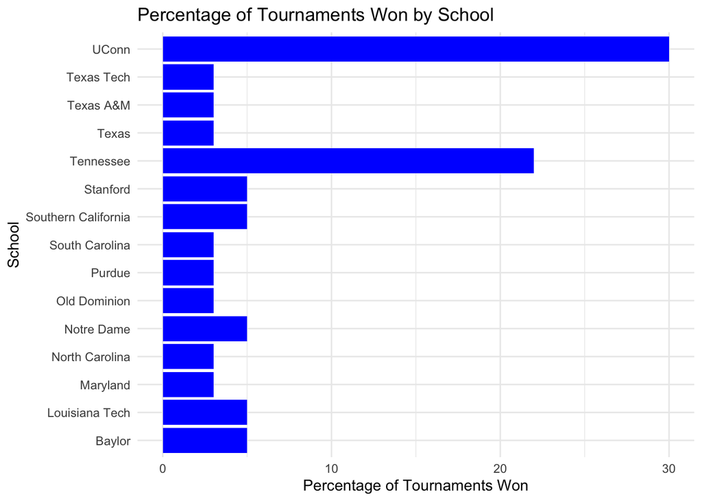

```r
library(ggplot2)
ggplot(winpercentage, aes(x = school, y = pct)) +
  geom_bar(stat = "identity", fill = "blue") +
  labs(title = "Percentage of Tournaments Won by School",
       x = "School",
       y = "Percentage of Tournaments Won") +
  theme_minimal() +
  coord_flip()
```

The patterns I see are: UConn and Tennessee are the two teams that have won the most, and the rest of the schools have won around 5% of the time.

## Question 2

```r
champ_names <- unique(ncaachamp$school)
winners <- wncaa %>%
  filter(school %in% champ_names)
```

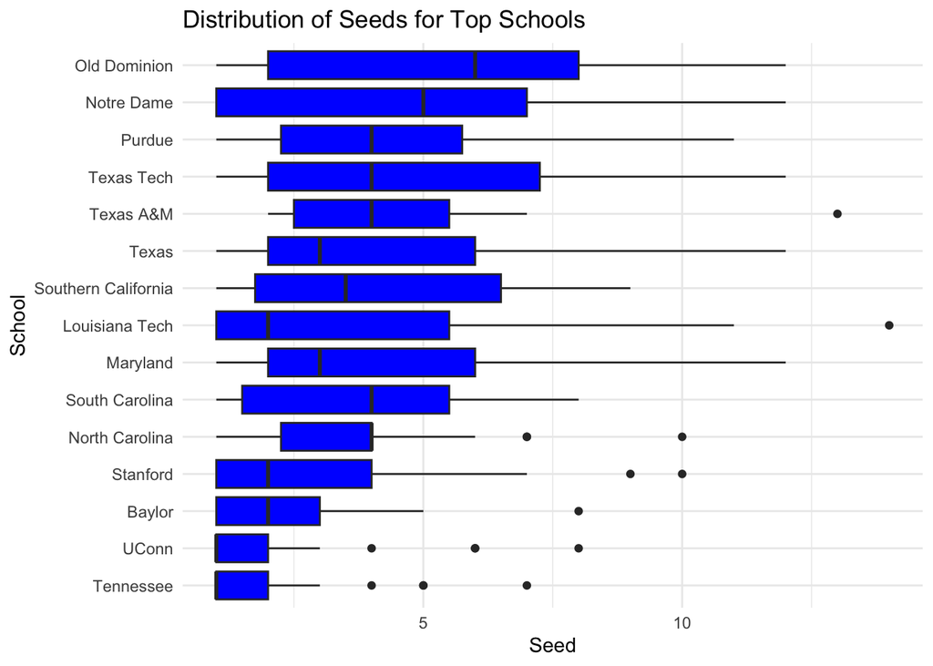

```r
ggplot(winners, aes(x = reorder(school, seed, na.rm=TRUE), y = seed)) +
  geom_boxplot(fill = "blue") +
  labs(title = "Distribution of Seeds for Top Schools",
       x = "School",
       y = "Seed") +
  theme_minimal() +
  coord_flip()
```

Given their continued dominance, UConn and Tennessee have both low medians, which means that they have mostly had high seeds. It is interesting to see that anything out of a 3 seed is an outlier for both schools.

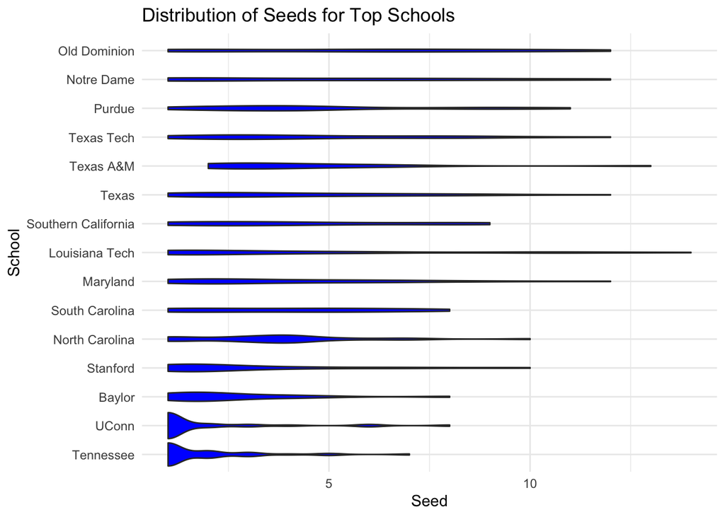

```r
ggplot(winners, aes(x = reorder(school, seed, na.rm = TRUE), y = seed)) +
  geom_violin(fill = "blue") +
  labs(title = "Distribution of Seeds for Top Schools",
       x = "School",
       y = "Seed") +
  theme_minimal() +
  coord_flip()
```

I think in general the boxplot is more helpful than the violin plot. On the boxplot you can see the median and the outliers more easily. The violin plot does give the viewer a better idea of the distribution.

## Question 3

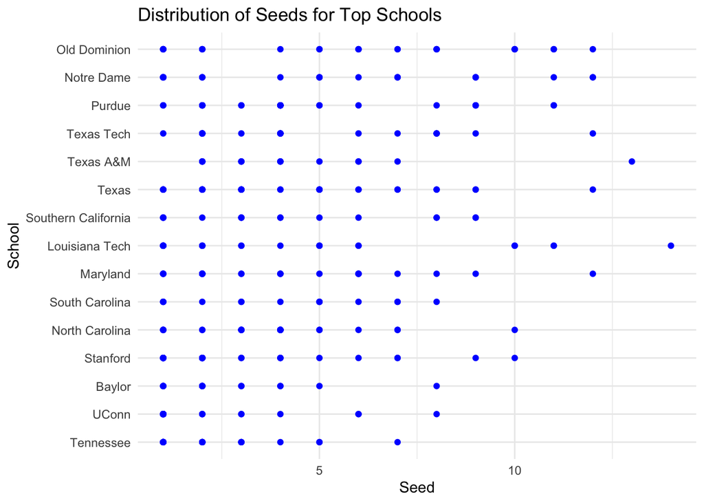

```r
ggplot(winners, aes(x = reorder(school, seed, na.rm = TRUE), y = seed)) +
  geom_point(color = "blue") +
  labs(title = "Distribution of Seeds for Top Schools",
       x = "School",
       y = "Seed") +
  theme_minimal() +
  coord_flip()
```

This is not an effective method of communicating the data because you cannot see the frequency of the data points or the distribution.

## Question 4

```r
library(dplyr)
winnerspercentage <- winners %>%
  group_by(school) %>%
  summarize_if(is.numeric, list(mean = mean, sd = sd))
glimpse(winnerspercentage)
```

```
Rows: 15
Columns: 27
$ school            <chr> "Baylor", "Louisiana Tech", "Maryland", "North Carol…
$ year_mean         <dbl> 2009.882, 1995.222, 2001.192, 2000.000, 2005.880, 19…
$ seed_mean         <dbl> 2.588235, 4.111111, 3.961538, 3.692308, 4.880000, 5.…
$ conf_w_mean       <dbl> 13.88235, NA, 10.92308, 10.92308, 13.08000, NA, 12.3…
$ conf_l_mean       <dbl> 2.941176, NA, 3.923077, 4.192308, 2.920000, NA, 4.23…
$ conf_percent_mean <dbl> 81.87059, NA, 73.52692, 72.34615, 81.62800, NA, 74.5…
$ reg_w_mean        <dbl> 27.70588, 25.88889, 23.57692, 24.57692, 24.60000, 23…
$ reg_l_mean        <dbl> 4.235294, 3.740741, 6.423077, 6.346154, 6.040000, 6.…
$ reg_percent_mean  <dbl> 86.48824, 87.38519, 78.16923, 79.39615, 79.86800, 78…
$ tourney_w_mean    <dbl> 2.588235, 2.407407, 1.730769, 1.807692, 2.480000, 1.…
$ tourney_l_mean    <dbl> 0.8823529, 0.9259259, 0.9615385, 0.9615385, 0.920000…
$ full_w_mean       <dbl> 30.29412, 28.29630, 25.30769, 26.34615, 27.08000, 24…
$ full_l_mean       <dbl> 5.117647, 4.666667, 7.384615, 7.269231, 6.960000, 7.…
$ full_percent_mean <dbl> 85.13529, 85.50000, 76.65385, 78.05385, 78.68400, 76…
$ year_sd           <dbl> 5.242642, 8.331282, 11.986723, 9.834633, 7.568135, 7…
$ seed_sd           <dbl> 1.839117, 3.866357, 2.835218, 2.149776, 3.822303, 3.…
$ conf_w_sd         <dbl> 3.218741, NA, 3.045299, 2.133974, 2.644491, NA, 2.19…
$ conf_l_sd         <dbl> 2.384077, NA, 2.431840, 2.039985, 2.271563, NA, 2.02…
$ conf_percent_sd   <dbl> 15.032081, NA, 16.048166, 13.431611, 14.244078, NA, …
$ reg_w_sd          <dbl> 3.869184, 2.965615, 4.535840, 3.431304, 5.033223, 3.…
$ reg_l_sd          <dbl> 2.795743, 2.767845, 3.227049, 2.869736, 3.899573, 2.…
$ reg_percent_sd    <dbl> 9.121258, 9.413522, 11.649473, 9.579164, 13.385929, …
$ tourney_w_sd      <dbl> 1.622453, 1.737798, 1.537731, 1.470217, 1.960442, 1.…
$ tourney_l_sd      <dbl> 0.3321056, 0.2668803, 0.1961161, 0.1961161, 0.276887…
$ full_w_sd         <dbl> 4.870379, 4.240962, 5.655222, 4.426667, 6.601263, 4.…
$ full_l_sd         <dbl> 2.934330, 2.841993, 3.262844, 2.973990, 3.984135, 3.…
$ full_percent_sd   <dbl> 8.944617, 9.584202, 11.698760, 9.545354, 13.257032, …
```

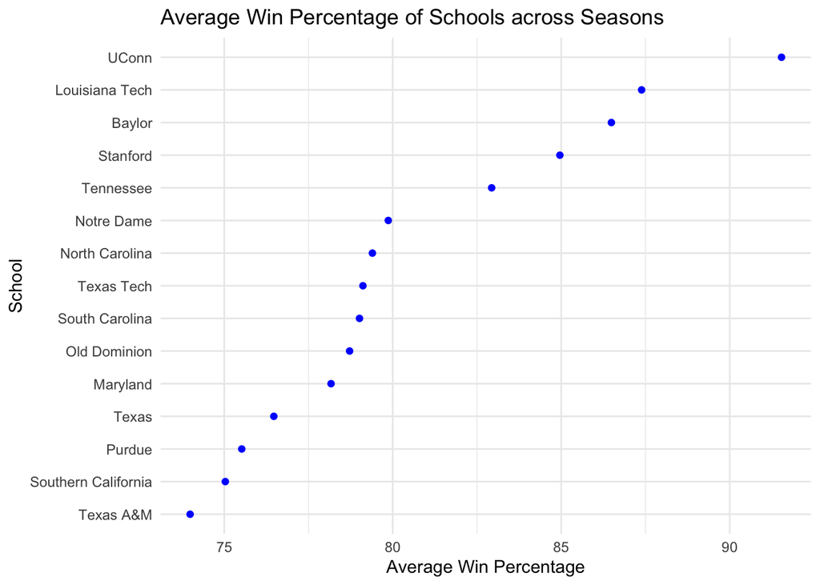

```r
library(ggplot2)
ggplot(winnerspercentage, aes(x = reorder(school, reg_percent_mean), y = reg_percent_mean)) +
  geom_point(color = "blue") +
  labs(title = "Average Win Percentage of Schools across Seasons",
       x = "School",
       y = "Average Win Percentage") +
  theme_minimal() +
  coord_flip()
```

The school that has the most titles (UConn), has the highest average win percentage, but most schools have around 77% average win percentage.

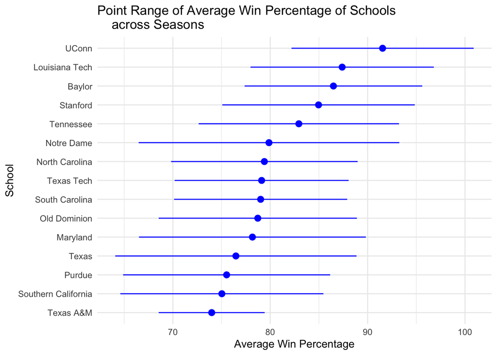

```r
library(ggplot2)
ggplot(winnerspercentage, aes(x = reorder(school, reg_percent_mean), y = reg_percent_mean)) +
  geom_pointrange(aes(ymin = reg_percent_mean - reg_percent_sd, ymax = reg_percent_mean + reg_percent_sd),
    color = "blue"
  ) +
  geom_point(color = "blue") +
  labs(
    title = "Point Range of Average Win Percentage of Schools
    across Seasons",
    x = "School",
    y = "Average Win Percentage"
  ) +
  theme_minimal() +
  coord_flip()
```

The school with the most narrow interval is Texas A&M. This means that there is less spread, and more consistency in their win percentage.

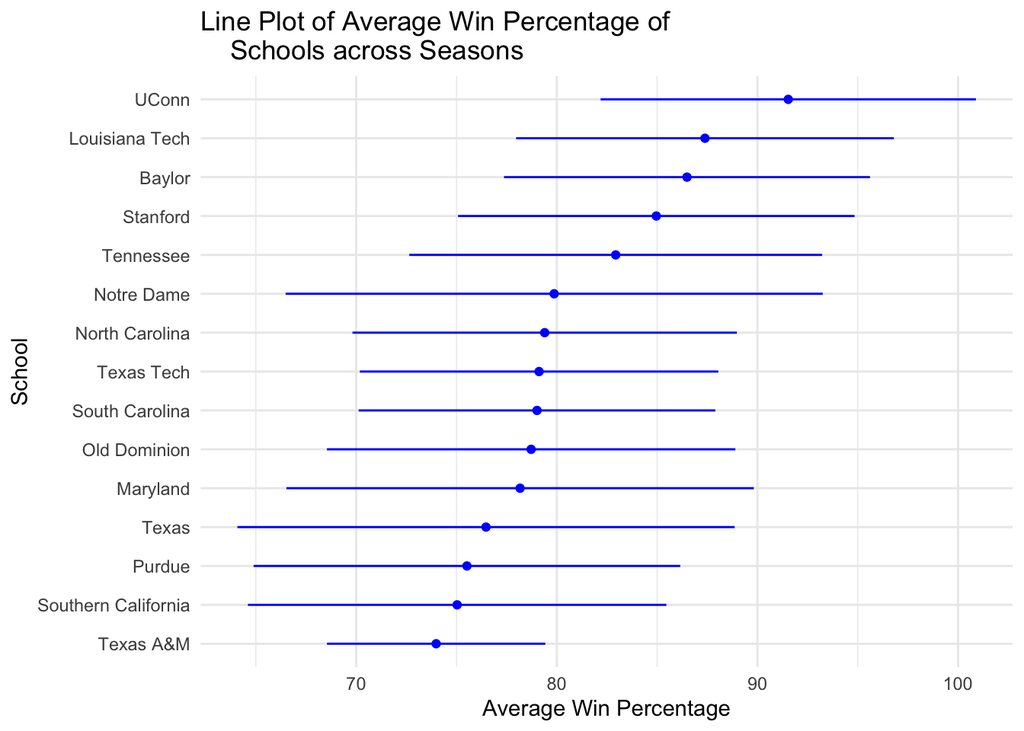

```r
ggplot(winnerspercentage, aes(x = reorder(school, reg_percent_mean), y = reg_percent_mean)) +
  geom_linerange(aes(ymin = reg_percent_mean - reg_percent_sd, ymax = reg_percent_mean + reg_percent_sd),
    color = "blue"
  ) +
  geom_point(color = "blue") +
  labs(
    title = "Line Plot of Average Win Percentage of
    Schools across Seasons",
    x = "School",
    y = "Average Win Percentage"
  ) +
  theme_minimal() +
  coord_flip()
```

I do think that the point range is more helpful, as I do think it is important to understand where the mean is, while the line plot emphasizes the range of the data points. I think it is more helpful to understand the mean/average win percentage than it is the variability in season performance, as we all know sports can be unpredictable. The line range can be helpful to see the overall trend, but it would be hard to differentiate between teams that have close ranges or overlapping ranges, for example, in this case it would be hard to differentiate between South Carolina and Old Dominion, but the point range that shows the mean helps us to see that SC has a slight advantage.